# Proyecto Final (Association Rules)

## MSSD: El dataset de sesiones de streaming

[The Music Streaming Sessions Dataset](https://research.atspotify.com/publications/the-music-streaming-sessions-dataset-short-paper/) fue desarrollado por Spotify para promover la investigación en modelado de escucha por parte de usuarios, interacciones en streaming, recuperación de información musical (MIR, por sus siglas en inglés) y recomendaciones con base a sesiones secuenciales.

Analiza una extracción del dataset MSSD por medio de reglas de asociación.

Instala el paquete [dplyr](https://dplyr.tidyverse.org/) para llevar preparar los datos de MSSD de tal forma que puedan ser analizados por medio de `arules`.

**CODE-06** Instala el paquete dplyr

```r
#TODO: Retira los comentarios la primera vez para instalar los paquetes.
#install.packages("dplyr")
```

Carga la librería dplyr.

```r
library(dplyr)
```

Lee el dataset MSSD y verifica su estructura.

```r
mssddf <- read.csv(url("https://storage.googleapis.com/data-mining-202104/mssd-log_mini.csv")) #../../../data/mssd-log_mini.csv
str(mssddf)
```

```
## 'data.frame':    167880 obs. of  21 variables:
##  $ session_id                     : chr  "0_00006f66-33e5-4de7-a324-2d18e439fc1e" "0_00006f66-33e5-4de7-a324-2d18e439fc1e" "0_00006f66-33e5-4de7-a324-2d18e439fc1e" "0_00006f66-33e5-4de7-a324-2d18e439fc1e" ...
##  $ session_position               : int  1 2 3 4 5 6 7 8 9 10 ...
##  $ session_length                 : int  20 20 20 20 20 20 20 20 20 20 ...
##  $ track_id_clean                 : chr  "t_0479f24c-27d2-46d6-a00c-7ec928f2b539" "t_9099cd7b-c238-47b7-9381-f23f2c1d1043" "t_fc5df5ba-5396-49a7-8b29-35d0d28249e0" "t_23cff8d6-d874-4b20-83dc-94e450e8aa20" ...
##  $ skip_1                         : chr  "false" "false" "false" "false" ...
##  $ skip_2                         : chr  "false" "false" "false" "false" ...
##  $ skip_3                         : chr  "false" "false" "false" "false" ...
##  $ not_skipped                    : chr  "true" "true" "true" "true" ...
##  $ context_switch                 : int  0 0 0 0 0 0 0 0 0 0 ...
##  $ no_pause_before_play           : int  0 1 1 1 1 1 1 1 1 1 ...
##  $ short_pause_before_play        : int  0 0 0 0 0 0 0 0 0 0 ...
##  $ long_pause_before_play         : int  0 0 0 0 0 0 0 0 0 0 ...
##  $ hist_user_behavior_n_seekfwd   : int  0 0 0 0 0 0 0 0 0 0 ...
##  $ hist_user_behavior_n_seekback  : int  0 0 0 0 0 0 0 0 0 0 ...
##  $ hist_user_behavior_is_shuffle  : chr  "true" "true" "true" "true" ...
##  $ hour_of_day                    : int  16 16 16 16 16 16 16 16 16 16 ...
##  $ date                           : chr  "2018-07-15" "2018-07-15" "2018-07-15" "2018-07-15" ...
##  $ premium                        : chr  "true" "true" "true" "true" ...
##  $ context_type                   : chr  "editorial_playlist" "editorial_playlist" "editorial_playlist" "editorial_playlist" ...
##  $ hist_user_behavior_reason_start: chr  "trackdone" "trackdone" "trackdone" "trackdone" ...
##  $ hist_user_behavior_reason_end  : chr  "trackdone" "trackdone" "trackdone" "trackdone" ...
```

Inspecciona la columna `session_id`.

```r
summary(mssddf$session_id)
```

```
##    Length     Class      Mode
##    167880 character character
```

```r
head(mssddf$session_id)
```

```
## [1] "0_00006f66-33e5-4de7-a324-2d18e439fc1e"
## [2] "0_00006f66-33e5-4de7-a324-2d18e439fc1e"
## [3] "0_00006f66-33e5-4de7-a324-2d18e439fc1e"
## [4] "0_00006f66-33e5-4de7-a324-2d18e439fc1e"
## [5] "0_00006f66-33e5-4de7-a324-2d18e439fc1e"
## [6] "0_00006f66-33e5-4de7-a324-2d18e439fc1e"
```

```r
length(unique(mssddf$session_id))
```

```
## [1] 10000
```

Inspecciona la columna `track_id_clean`.

```r
summary(mssddf$track_id_clean)
```

```
##    Length     Class      Mode
##    167880 character character
```

```r
head(mssddf$track_id_clean)
```

```
## [1] "t_0479f24c-27d2-46d6-a00c-7ec928f2b539"
## [2] "t_9099cd7b-c238-47b7-9381-f23f2c1d1043"
## [3] "t_fc5df5ba-5396-49a7-8b29-35d0d28249e0"
## [4] "t_23cff8d6-d874-4b20-83dc-94e450e8aa20"
## [5] "t_64f3743c-f624-46bb-a579-0f3f9a07a123"
## [6] "t_c815228b-3212-4f9e-9d4f-9cb19b248184"
```

```r
length(unique(mssddf$track_id_clean))
```

```
## [1] 50704
```

Consulta el paper [The Music Streaming Sessions Dataset](https://arxiv.org/abs/1901.09851) y responde a las siguientes preguntas:

- ¿Cuál es el propósito de `session id`? (**NOTE-23**): Es el id que identifica a la sesión que se analiza y que acumula a todas las sesiones que se hicieron.
- ¿Cuál es el propósito de `track id`? (**NOTE-24**): Es para saber que canción es la que se escuchó
- ¿Consideras que las otras columnas del dataset son aplicables para análisis por medio de reglas de asociación, justifica tu respuesta? (**NOTE-25**): Sí, ya que con las otras columnas te puede decir que tanta relación existe entre si. Por ejemplo, si la canción gustó y no se paro antes de reproducirse.

Inspecciona la estructura de `y`, el dataset preparado.

```r
x <- mssddf %>% select(session_id, track_id_clean) %>% group_by(session_id)
y <- as.data.frame(x)
str(y)
```

```
## 'data.frame':    167880 obs. of  2 variables:
##  $ session_id    : chr  "0_00006f66-33e5-4de7-a324-2d18e439fc1e" "0_00006f66-33e5-4de7-a324-2d18e439fc1e" "0_00006f66-33e5-4de7-a324-2d18e439fc1e" "0_00006f66-33e5-4de7-a324-2d18e439fc1e" ...
##  $ track_id_clean: chr  "t_0479f24c-27d2-46d6-a00c-7ec928f2b539" "t_9099cd7b-c238-47b7-9381-f23f2c1d1043" "t_fc5df5ba-5396-49a7-8b29-35d0d28249e0" "t_23cff8d6-d874-4b20-83dc-94e450e8aa20" ...
```

Descarga la librería `dplyr`

```r
#Descargamos dplyr porque enmascara otras funciones y no es requerida en lo sucesivo
detach(package:dplyr)
```

Genera la representación de transacciones para `arules` del dataset MSSD y visualiza la salida **R Console**.

```r
mssdtx <- as(split(y[,"track_id_clean"], y["session_id"]), "transactions")
#Trabajaremos con una muestra del 80% de las transacciones
numSessions <- round(nrow(mssdtx) * 0.8)
set.seed(DIGITOS_MATRICULA)
mssdtx <- sample(mssdtx, numSessions)
summary(mssdtx)
```

```
## transactions as itemMatrix in sparse format with
##  8000 rows (elements/itemsets/transactions) and
##  50704 columns (items) and a density of 0.0002883155
##
## most frequent items:
## t_bacf06d3-9185-4183-84ea-ff0db51475ce t_5718ab08-3a15-4d3f-9e63-42b2f6805e31
##                                    914                                    609
## t_77b02acb-1b1f-4b36-b8fc-2c3e01892b9a t_8c4d29b1-e0bf-464c-88f7-ac19240cbba0
##                                    523                                    522
## t_a66ea088-b357-449a-8a1e-64dd0b8d6cb5                                (Other)
##                                    522                                 113860
##
## element (itemset/transaction) length distribution:
## sizes
##    1    2    3    4    5    6    7    8    9   10   11   12   13   14   15   16
##    1   21   19   34   89  133  156  245  312  667  613  571  438  484  438  508
##   17   18   19   20
##  372  802  522 1575
##
##    Min. 1st Qu.  Median    Mean 3rd Qu.    Max.
##    1.00   11.00   15.00   14.62   19.00   20.00
##
## includes extended item information - examples:
##                                   labels
## 1 t_00007fba-6bd3-449d-85dd-54d4aea397c2
## 2 t_0000dc06-0c00-4a09-9dc6-3bdad9c6f0e8
## 3 t_00020dc1-1b82-43e9-8327-77b074bdf626
##
## includes extended transaction information - examples:
##                               transactionID
## 2626 0_03cc8e79-1685-482b-9b3c-9178848b8488
## 9276 0_0da52861-4afa-498b-9cf7-e8efce4f381e
## 6655 0_09bcb842-e789-48c7-902b-79e14a0de174
```

Ejecuta el algoritmo apriori con los parámetros por omisión.

```r
rules <- apriori(mssdtx)
```

```
## Apriori
##
## Parameter specification:
##  confidence minval smax arem  aval originalSupport maxtime support minlen
##         0.8    0.1    1 none FALSE            TRUE       5     0.1      1
##  maxlen target  ext
##      10  rules TRUE
##
## Algorithmic control:
##  filter tree heap memopt load sort verbose
##     0.1 TRUE TRUE  FALSE TRUE    2    TRUE
##
## Absolute minimum support count: 800
##
## set item appearances ...[0 item(s)] done [0.00s].
## set transactions ...[43509 item(s), 8000 transaction(s)] done [0.12s].
## sorting and recoding items ... [1 item(s)] done [0.01s].
## creating transaction tree ... done [0.00s].
## checking subsets of size 1 done [0.00s].
## writing ... [0 rule(s)] done [0.00s].
## creating S4 object  ... done [0.01s].
```

```r
summary(rules)
```

```
## set of 0 rules
```

- ¿Qué factores están asociados con que el algoritmo `apriori` con parámetros por omisión no haya producido ninguna regla de asociación, justifica tu respuesta? (**NOTE-29**): Que debe de tener RHS y LHS, ya que mediante eso se conforman las reglas de asociación.
- ¿Qué riesgos identificas con la asignación de valores muy bajos en los parámetros de `support` y `confidence` al invocar el algoritmo `apriori`? Si se tiene un número bajo en cualquiera de las dos, ya sea support o confidence, esto quiere decir que la regla que se quiere analizar no tiene valor o no genera confianza.

```r
#TODO: Configura las variables SUPP y CONF para generar al menos 250 reglas de asociación
SUPP = 0.02
CONF = 0.001
rules <- apriori(mssdtx, parameter = list(support = SUPP, confidence = CONF))
```

```
## Apriori
##
## Parameter specification:
##  confidence minval smax arem  aval originalSupport maxtime support minlen
##       0.001    0.1    1 none FALSE            TRUE       5    0.02      1
##  maxlen target  ext
##      10  rules TRUE
##
## Algorithmic control:
##  filter tree heap memopt load sort verbose
##     0.1 TRUE TRUE  FALSE TRUE    2    TRUE
##
## Absolute minimum support count: 160
##
## set item appearances ...[0 item(s)] done [0.00s].
## set transactions ...[43509 item(s), 8000 transaction(s)] done [0.12s].
## sorting and recoding items ... [55 item(s)] done [0.00s].
## creating transaction tree ... done [0.00s].
## checking subsets of size 1 2 3 4 5 6 7 8 done [0.00s].
## writing ... [3994 rule(s)] done [0.00s].
## creating S4 object  ... done [0.01s].
```

```r
summary(rules)
```

```
## set of 3994 rules
##
## rule length distribution (lhs + rhs):sizes
##    1    2    3    4    5    6    7    8
##   55  258  591 1048 1095  684  231   32
##
##    Min. 1st Qu.  Median    Mean 3rd Qu.    Max.
##   1.000   4.000   5.000   4.504   5.000   8.000
##
## summary of quality measures:
##     support          confidence         coverage            lift
##  Min.   :0.02000   Min.   :0.02013   Min.   :0.02000   Min.   : 1.00
##  1st Qu.:0.02088   1st Qu.:0.86070   1st Qu.:0.02200   1st Qu.:13.42
##  Median :0.02162   Median :0.93333   Median :0.02363   Median :20.15
##  Mean   :0.02255   Mean   :0.88552   Mean   :0.03933   Mean   :18.06
##  3rd Qu.:0.02325   3rd Qu.:0.97740   3rd Qu.:0.02675   3rd Qu.:22.35
##  Max.   :0.11425   Max.   :1.00000   Max.   :1.00000   Max.   :29.58
##      count
##  Min.   :160.0
##  1st Qu.:167.0
##  Median :173.0
##  Mean   :180.4
##  3rd Qu.:186.0
##  Max.   :914.0
##
## mining info:
##    data ntransactions support confidence
##  mssdtx          8000    0.02      0.001
```

```
## To reduce overplotting, jitter is added! Use jitter = 0 to prevent jitter.
```

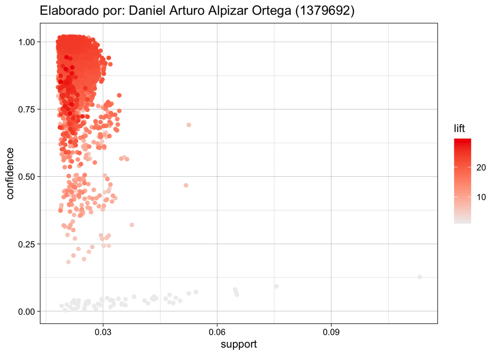

```r
try(
  plot(rules, main=paste0("Elaborado por: ", NOMBRE_COMPLETO, " (", DIGITOS_MATRICULA, ")" ))
)
```

Inspecciona las reglas con mayor lift

```r
inspect(head(sort(rules, by = "lift")))
```

```
##     lhs                                         rhs                                       support confidence coverage     lift count
## [1] {t_4319026b-d2b5-478d-bf37-8f2873645c5c,
##      t_e8fa3463-7ef7-4ca5-8e65-2df979012c34} => {t_9a03f300-6504-4c7a-92b1-4cd88354ee74} 0.020250  0.8393782 0.024125 29.58161   162
## [2] {t_32270005-26a1-4763-8ba5-44fcc15f9914,
##      t_78b908e3-62db-4021-ac90-2ed146bcea8d} => {t_52fc9bcf-ce50-43fc-9498-c2c8421a33e7} 0.020000  0.9195402 0.021750 28.73563   160
## [3] {t_e8fa3463-7ef7-4ca5-8e65-2df979012c34,
##      t_eb0063cc-948f-41d4-9dab-bf4b0e70d21e} => {t_4319026b-d2b5-478d-bf37-8f2873645c5c} 0.020875  0.8978495 0.023250 28.73118   167
## [4] {t_4319026b-d2b5-478d-bf37-8f2873645c5c,
##      t_9a03f300-6504-4c7a-92b1-4cd88354ee74} => {t_e8fa3463-7ef7-4ca5-8e65-2df979012c34} 0.020250  0.9585799 0.021125 28.40237   162
## [5] {t_e8308b79-41cf-4b31-b159-df093b592b41} => {t_bf17338d-830d-4890-b8e9-8ba41bb3349f} 0.020875  0.7877358 0.026500 28.00839   167
## [6] {t_bf17338d-830d-4890-b8e9-8ba41bb3349f} => {t_e8308b79-41cf-4b31-b159-df093b592b41} 0.020875  0.7422222 0.028125 28.00839   167
```

Graba y publica un video (puede ser un video publicado de forma privada en YouTube u otro servicio similar) de 3 a 5 minutos explicando lo siguiente:

- Nombre y carrera.
- Concepto de association rules.
- Diferencia entre los conceptos de transacciones y reglas.
- Estrategia seguida para descubrir las reglas de interés en el dataset MSSD de este proyecto.
- Interpretación de la primera regla listada en el chunk anterior con el código `inspect(head(sort(rules, by = "lift")))` aclarando qué significan los datos listados en lhs, rhs y la interpretación de todas sus métricas.
- Provee el enlace al video aquí: **NOTE-30**

## Entrega del proyecto final

- Verifica que el notebook corra de principio a fin sin errores y produzca los resultados esperados.
- Verifica que hayas realizado todas las actividades de programación indicadas con **CODE-nn**
- Verifica que hayas respondido a todas las preguntas **NOTE-nn**
- Verifica que hayas producido, publicado y escrito el enlace al video en el notebook.
- Guarda el archivo de markup (rmd) de forma local.
- Genera el PDF del notebook por medio del comando Knit (ya sea directo a PDF o Word y posteriormente Save As/PDF).
- No se recibirán proyectos en formato PDF con texto libre y capturas de pantalla.
- Publica el código de tu notebook a tu respositorio de GitHub por medio de los comandos `commit` y `push`.
- Envía el documento PDF por medio de mensaje personal a @marciano en Slack `naylacommunity` junto con el enlace a tu repositorio de GitHub.

**Fecha límite de entrega: Sábado 5 de junio al cierre del día.**